# Comparison of protein length distirbutions

# Rationale

We have over 50,000 predicted proteins from RSSW. This seems like way too many. My hypothesis that because of the fragemented assembly and the low RNA-Seq coverage, many of the RSSW genes are split. To test this, compare the number and length distributions of proteins from RSSW and boll weevil.

# Libraries and data

Seqinr package to read and analyze sequence data

```r
library(seqinr)
```

Boll weevil proteins from NCBI reference genome.

```r
bollWeevilData <- "bollWeevilProteins.fasta"
```

RSSW proteins from BRAKER2

```r
rsswData <- "../braker.proteins.fasta"
```

```r
bollWeevil <- read.fasta(bollWeevilData)
rssw <- read.fasta(rsswData)
```

# Analysis of number and length distribution of proteins

```r
bollWeevilLengths <- getLength(bollWeevil)
rsswLengths <- getLength(rssw)
```

How many proteins total?

```r
length(bollWeevilLengths)
```

```
## [1] 23731
```

```r
length(rsswLengths)
```

```
## [1] 50192
```

So yes, there are a lot more predicted proteins for rssw as boll weevil

```r
length(rsswLengths) / length(bollWeevilLengths)
```

```
## [1] 2.115039
```

More than twice as many in fact.

What’s the mean protein length for each species?

```r
mean(bollWeevilLengths)
```

```
## [1] 698.2943
```

```r
mean(rsswLengths)
```

```
## [1] 296.5304
```

```r
mean(rsswLengths) / mean(bollWeevilLengths)
```

```
## [1] 0.4246497
```

So the average RSSW protein is half the length of the average boll weevil protein.

Finally, let’s compare the distributions. Because there is a long tail of a few very large proteins for boll weevil, plot the distribution of $\log_{10} length$

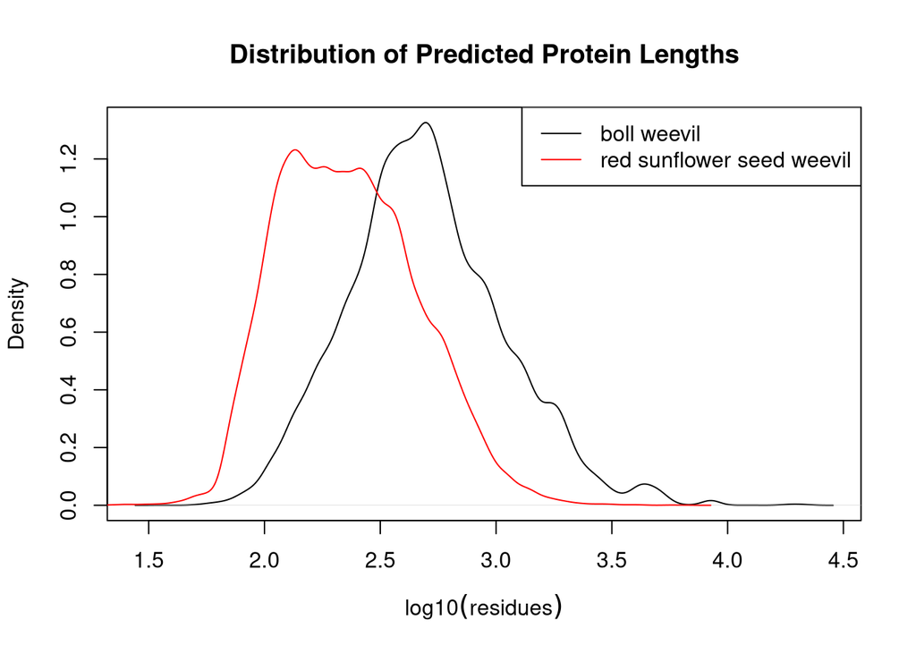

```r
plot(density(log10(bollWeevilLengths)),
     main = "Distribution of Predicted Protein Lengths",
     xlab = expression(log10(residues)))

lines(density(log10(rsswLengths)),
      col = "red")

legend("topright",
       legend = c("boll weevil",
                  "red sunflower seed weevil"),
       col = c("black",
               "red"),
       lty = "solid")
```

```r
dev.copy2pdf(file = "proteinLengthDistribution.pdf")
```

So, our hypothesis is supported looks like we have a bunch of split gene models for RSSW.